# Data 612 Research 1

Anthony Pagan

6/11/2020

# Introduction

The first chapter of “Building a Recommendation System with R” categorizes recommender systems as follows:

- Collaborate filters - group users of similar interest
- Content-based systems - takes the similarity of items and link to what users have liked in the past.
- Knowledge based systems - takes consideration of the items features and user preferences
- Hybrid systems - combine features of various recommender systems.

# Knowledge Based System

The Meta-Score Magic recommender system would be an example of a knowledge based system. It takes the weighted score of the of each critic and gives critics with “better quality” critiques a higher value. The article doesn’t say how one would quantify a “better quality”. I would suggest that they include user reviews as part of the rating . If the critic rating has a history of matching user reviews closely, their weight should be higher. Without some form of link to the real reviews, it leave the possibility of a bias on critic ratings.

# Collaborative filtering System

The Rotten Tomatoes recommender system is an example of a collaborative filtering recommender system. It takes the reviews of all viewers. When a movie review has 60% positive ratings it gets a Tomato. The issue with this type of system was discussed in the posted “Attacks on Recommender System” article. The article shows how users can purposely give bad reviews of movies for political , social reason that are not based on an actual movie review. This recommender should include an algorithm to detect biases and hidden user agendas.

# Content Based System

The movie recommender systems used in Netflix and Amazon would be examples of content based recommender systems. These systems uses movies watched and /or liked in the past and recommend similar movies

# Hybrid Recommender System

The article below shows an example of a hybrid recommender system. The examples uses the MovieLens 20M Dataset.

https://towardsdatascience.com/creating-a-hybrid-content-collaborative-movie-recommender-using-deep-learning-cc8b431618af

In this article, the hybrid recommender system uses content-based movie data and a deep entity embedding neural network that learns collaborative-based movies from ratings data. The embedding in the neural networks finds similarities in movies by using a cosine similarity score from -1 to 1. Movie vectors with a cosine similarity score closer to 1 are more similar , a 0 score has no similarity and q negative value are movies that are dissimilar.

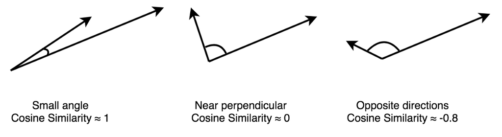

# Conclusion

Overall , a hybrid system seems to be the most flexible and will very like recommend item closer to a user’s preference. However, additional bias-variance tradeoff analysis will be required to draw a final conclusion.

# References

Building a Recommendation System with R, Suresh K Gorakala and Michele Usuelli, Packt Publishing, 2015.

https://www.rottentomatoes.com/about

https://www.metacritic.com/about-metascores

https://www.washingtonpost.com/news/morning-mix/wp/2017/04/19/wisdom-of-the-crowd-imdb-users-gang-up-on-the-promise-before-it-even-opens/

https://towardsdatascience.com/creating-a-hybrid-content-collaborative-movie-recommender-using-deep-learning-cc8b431618af